# **Master analysis for skin microbiome project**

[output not shown]

[output not shown]

Test for significant differences between groups

[output not shown]

[output not shown]

[output not shown]

[output not shown]

Analysis of richness from rarefied OTU table

```
## `set.seed(552)` was used to initialize repeatable random subsampling.
## Please record this for your records so others can reproduce.
## Try `set.seed(552); .Random.seed` for the full vector
## ...
## 561OTUs were removed because they are no longer
## present in any sample after random subsampling
##
## ...
```

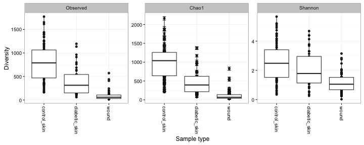

Significance testing on alpha diversity results

```r
alpha_estimates<-estimate_richness(rare_mydata_sub, split = TRUE, measures = c("Observed", "Chao1", "Shannon"))
#Sort samples in alpha_estimates by sample name
alpha_estimates_sorted<-alpha_estimates[order(rownames(alpha_estimates)),]
#sort samples in sample_data(rare_mydata_sub) by sample name
sorted_sampledata<-sample_data(rare_mydata_sub)[order(rownames(sample_data(rare_mydata_sub))),]
#Create a vector of which group each sample belongs to from the sampletype1 column and add to alpha estimates file
group<-sorted_sampledata$sampletype1
alpha_estimates_sorted<-cbind(alpha_estimates_sorted, group)
rm(group)
#Sort sorted_alpha_estimates by group
alpha_estimates_sorted<-alpha_estimates_sorted[order(alpha_estimates_sorted$group),]
#Get median, min and max "Observed" values for the three groups under "group"
library(plyr)
median_otus<-ddply(alpha_estimates_sorted, .(group), summarize, median_otus=median(Observed), max=max(Observed), min=min(Observed))
median_otus
```

```
##           group median_otus  max min
## 1  control_skin       789.0 1772 164
## 2 diabetic_skin       314.0 1195  60
## 3         wound        58.5  572  16
```

```r
#Code from Steve Bush to assess statistical difference in diversity between groups.
library(MASS)
fullmodel<-glm.nb(Observed ~factor(group),data=alpha_estimates_sorted)
reducedmodel<- glm.nb (Observed ~1,data=alpha_estimates_sorted)
library(lmtest)
lrtest(fullmodel, reducedmodel)
```

```
## Likelihood ratio test
##
## Model 1: Observed ~ factor(group)
## Model 2: Observed ~ 1
##   #Df  LogLik Df Chisq Pr(>Chisq)
## 1   4 -1258.4
## 2   2 -1354.8 -2 192.9  < 2.2e-16 ***
## ---
## Signif. codes:  0 '***' 0.001 '**' 0.01 '*' 0.05 '.' 0.1 ' ' 1
```

```r
#Wilcox rank sum test
wilcox.test(Observed ~ group, alpha_estimates_sorted, subset=group%in%c("control_skin", "diabetic_skin"))
```

```
##
##  Wilcoxon rank sum test with continuity correction
##
## data:  Observed by group
## W = 2667.5, p-value = 4.889e-08
## alternative hypothesis: true location shift is not equal to 0
```

```r
wilcox.test(Observed ~ group, alpha_estimates_sorted, subset=group%in%c("wound", "diabetic_skin"))
```

```
##
##  Wilcoxon rank sum test with continuity correction
##
## data:  Observed by group
## W = 2539.5, p-value = 7.913e-13
## alternative hypothesis: true location shift is not equal to 0
```

```r
wilcox.test(Observed ~ group, alpha_estimates_sorted, subset=group%in%c("wound", "control_skin"))
```

```
##
##  Wilcoxon rank sum test with continuity correction
##
## data:  Observed by group
## W = 5431, p-value < 2.2e-16
## alternative hypothesis: true location shift is not equal to 0
```

```r
#Now stats for Chao1 and Shannon
fullmodel<-glm.nb(Chao1 ~factor(group),data=alpha_estimates_sorted)
reducedmodel<- glm.nb (Chao1 ~1,data=alpha_estimates_sorted)
lrtest(fullmodel, reducedmodel)
```

```
## Likelihood ratio test
##
## Model 1: Chao1 ~ factor(group)
## Model 2: Chao1 ~ 1
##   #Df  LogLik Df  Chisq Pr(>Chisq)
## 1   4 -1300.4
## 2   2 -1394.7 -2 188.69  < 2.2e-16 ***
## ---
## Signif. codes:  0 '***' 0.001 '**' 0.01 '*' 0.05 '.' 0.1 ' ' 1
```

```r
wilcox.test(Chao1 ~ group, alpha_estimates_sorted, subset=group%in%c("control_skin", "diabetic_skin"))
```

```
##
##  Wilcoxon rank sum test with continuity correction
##
## data:  Chao1 by group
## W = 2727, p-value = 7.569e-09
## alternative hypothesis: true location shift is not equal to 0
```

```r
wilcox.test(Chao1 ~ group, alpha_estimates_sorted, subset=group%in%c("wound", "diabetic_skin"))
```

```
##
##  Wilcoxon rank sum test with continuity correction
##
## data:  Chao1 by group
## W = 2534, p-value = 1.019e-12
## alternative hypothesis: true location shift is not equal to 0
```

```r
wilcox.test(Chao1 ~ group, alpha_estimates_sorted, subset=group%in%c("wound", "control_skin"))
```

```
##
##  Wilcoxon rank sum test with continuity correction
##
## data:  Chao1 by group
## W = 5424, p-value < 2.2e-16
## alternative hypothesis: true location shift is not equal to 0
```

```r
fullmodel<-glm.nb(Shannon ~factor(group),data=alpha_estimates_sorted)
reducedmodel<- glm.nb (Shannon ~1,data=alpha_estimates_sorted)
lrtest(fullmodel, reducedmodel)
```

```
## Likelihood ratio test
##
## Model 1: Shannon ~ factor(group)
## Model 2: Shannon ~ 1
##   #Df  LogLik Df  Chisq Pr(>Chisq)
## 1   4 -285.34
## 2   2 -305.70 -2 40.737  1.426e-09 ***
## ---
## Signif. codes:  0 '***' 0.001 '**' 0.01 '*' 0.05 '.' 0.1 ' ' 1
```

```r
wilcox.test(Shannon ~ group, alpha_estimates_sorted, subset=group%in%c("control_skin", "diabetic_skin"))
```

```
##
##  Wilcoxon rank sum test with continuity correction
##
## data:  Shannon by group
## W = 2037, p-value = 0.04156
## alternative hypothesis: true location shift is not equal to 0
```

```r
wilcox.test(Shannon ~ group, alpha_estimates_sorted, subset=group%in%c("control_skin", "diabetic_skin"), correct=FALSE)
```

```
##
##  Wilcoxon rank sum test
##
## data:  Shannon by group
## W = 2037, p-value = 0.04129
## alternative hypothesis: true location shift is not equal to 0
```

```r
wilcox.test(Shannon ~ group, alpha_estimates_sorted, subset=group%in%c("wound", "diabetic_skin"))
```

```
##
##  Wilcoxon rank sum test with continuity correction
##
## data:  Shannon by group
## W = 2013, p-value = 0.0001093
## alternative hypothesis: true location shift is not equal to 0
```

```r
wilcox.test(Shannon ~ group, alpha_estimates_sorted, subset=group%in%c("wound", "control_skin"))
```

```
##
##  Wilcoxon rank sum test with continuity correction
##
## data:  Shannon by group
## W = 4576, p-value = 3.869e-12
## alternative hypothesis: true location shift is not equal to 0
```

Plots of top 20 OTUs by average abundance per group.

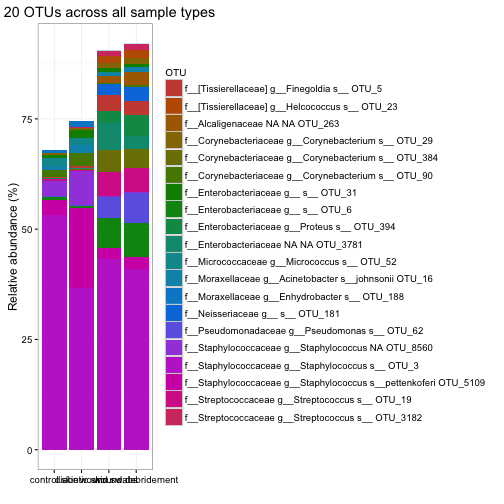

```r
#Using apply to get average abundances of OTUs per group.  First create vectors of names of each group of samples
control_skin_samples<-rownames(sample_data(rare_mydata_sub)[sample_data(rare_mydata_sub)[,"sampletype1"]=="control_skin"])
diabetic_skin_samples<-rownames(sample_data(rare_mydata_sub)[sample_data(rare_mydata_sub)[,"sampletype1"]=="diabetic_skin"])
wound_swab_samples<-rownames(sample_data(rare_mydata_sub)[sample_data(rare_mydata_sub)[,"sampletype2"]=="wound_swab"])
wound_deb_samples<-rownames(sample_data(rare_mydata_sub)[sample_data(rare_mydata_sub)[,"sampletype2"]=="wound_deb"])
#Now apply the mean function only to columns of the OTU table that correspond to a sample from each of the vectors of groups sample names. i.e. gets mean abundance for each OTU for each of the 4 sample groups defined above.
mean_abund_control_skin_otus<-as.matrix(apply(otu_table(rare_mydata_sub)[,control_skin_samples],1, FUN=mean))
stdev_abund_control_skin_otus<-as.matrix(apply(otu_table(rare_mydata_sub)[,control_skin_samples],1, FUN=sd))
mean_abund_diabetic_skin_otus<-as.matrix(apply(otu_table(rare_mydata_sub)[,diabetic_skin_samples],1, FUN=mean))
stdev_abund_diabetic_skin_otus<-as.matrix(apply(otu_table(rare_mydata_sub)[,diabetic_skin_samples],1, FUN=sd))
mean_abund_wound_swab_otus<-as.matrix(apply(otu_table(rare_mydata_sub)[,wound_swab_samples],1, FUN=mean))
mean_abund_wound_deb_otus<-as.matrix(apply(otu_table(rare_mydata_sub)[,wound_deb_samples],1, FUN=mean))
#Now bind those results into a new table and define row (OTU) and column (sample) names.
average_abund_all<-as.matrix(cbind(mean_abund_control_skin_otus,mean_abund_diabetic_skin_otus,mean_abund_wound_swab_otus,mean_abund_wound_deb_otus))
rownames(average_abund_all)<-rownames(otu_table(rare_mydata_sub))
colnames(average_abund_all)<-c("control skin","diabetic skin","wound swabs","wound debridement")
#Create table of just skin otus with average abundace and standard deviation for control and diabetic groups
average_abund_sd_skin<-as.matrix(cbind(mean_abund_control_skin_otus,stdev_abund_control_skin_otus, mean_abund_diabetic_skin_otus,stdev_abund_diabetic_skin_otus))
rownames(average_abund_sd_skin)<-rownames(otu_table(rare_mydata_sub))
colnames(average_abund_sd_skin)<-c("control skin average","control skin sd","diabetic skin average","diabetic skin sd")
#Sort abund_all table by the 20 most abundant accross all sample types, after converting counts to propotions.
average_abund_all<-((average_abund_all/30000)*100)
average_abund_all<-average_abund_all[order(-rowSums(average_abund_all)),]
top20<-average_abund_all[1:20,]
top20<-data.frame(top20)
top20<-cbind(top20,tax_table(rare_mydata_sub)[rownames(top20),])
top20<-top20[,c(1,2,3,4,9,10,11)]
top20$OTU<-paste(top20$Family,top20$Genus, top20$Species, rownames(top20))
top20<-top20[,c(1, 2, 3, 4,8)]
#Now melt data to the right format for ggplot
library(reshape)
top20<-melt(top20)
#Now plot a stacked barplot
ggplot(top20, aes(x=variable, y=value, fill=OTU))+geom_bar(stat="identity")+scale_fill_hue(l=50) + labs(title="Top 20 OTUs across all sample types", x="", y="Relative abundance (%)") + theme(legend.title=element_text(size=10))
```

```r
#Still need to figure our best colour scale and labels - will do this later.
```

Plots of top 10 OTUs by average abundance per group in skin only.

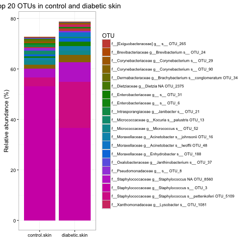

```r
#Use vectors of names of each group of samples created above and apply the mean function only to columns of the OTU table that correspond to a sample from each of the vectors of groups sample names. i.e. get mean abundance for each OTU for each of the 2 sample groups.
mean_abund_control_skin_otus<-as.matrix(apply(otu_table(rare_mydata_sub)[,control_skin_samples],1, FUN=mean))
mean_abund_diabetic_skin_otus<-as.matrix(apply(otu_table(rare_mydata_sub)[,diabetic_skin_samples],1, FUN=mean))
#Now bind those results into a new table and define row (OTU) and column (sample) names.
average_abund_skin<-as.matrix(cbind(mean_abund_control_skin_otus,mean_abund_diabetic_skin_otus))
rownames(average_abund_skin)<-rownames(otu_table(rare_mydata_sub))
colnames(average_abund_skin)<-c("control skin","diabetic skin")
#Now sort table by the 20 most abundant across all sample types, after converting counts to propotions.
average_abund_skin<-((average_abund_skin/30000)*100)
average_abund_skin<-average_abund_skin[order(-rowSums(average_abund_skin)),]
top20skin<-average_abund_skin[1:20,]
top20skin<-data.frame(top20skin)
top20skin<-cbind(top20skin,tax_table(rare_mydata_sub)[rownames(top20skin),])
top20skin<-top20skin[,c(1,2,7,8,9)]
top20skin$OTU<-paste(top20skin$Family,top20skin$Genus, top20skin$Species, rownames(top20skin))
top20skin<-top20skin[,c(1, 2,6)]
#Now melt data to the right format for ggplot
top20skin<-melt(top20skin)
#Now plot a stacked barplot
ggplot(top20skin, aes(x=variable, y=value, fill=OTU))+geom_bar(stat="identity")+scale_fill_hue(l=50)+ labs(title="Top 20 OTUs in control and diabetic skin", x="", y="Relative abundance (%)")+ theme(legend.text=element_text(size=8))
```

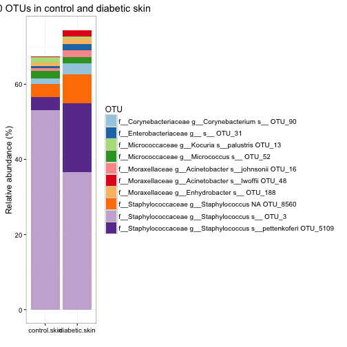

```r
#Repeat for top 10
top10skin<-average_abund_skin[1:10,]
top10skin<-data.frame(top10skin)
top10skin<-cbind(top10skin,tax_table(rare_mydata_sub)[rownames(top10skin),])
top10skin<-top10skin[,c(1,2,7,8,9)]
top10skin$OTU<-paste(top10skin$Family,top10skin$Genus, top10skin$Species, rownames(top10skin))
#Write file for making nice graphics in another program if necessary
write.table(top10skin, file="r_data/top10skin.txt", sep="\t")
top10skin<-top10skin[,c(1, 2,6)]
#Now melt data to the right format for ggplot
top10skin<-melt(top10skin)
#Now plot a stacked barplot
ggplot(top10skin, aes(x=variable, y=value, fill=OTU))+geom_bar(stat="identity")+ labs(title="Top 10 OTUs in control and diabetic skin", x="", y="Relative abundance (%)")+ theme(legend.text=element_text(size=10))+scale_fill_brewer(palette="Paired")
```

Wound taxa plots top 10 or 20 overall, and by patient over time

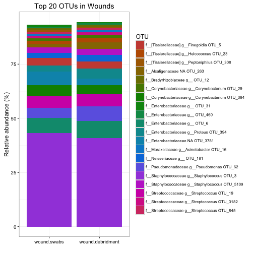

```r
#Create vector of sample names for wounds and wond debridement
diabetic_woundswab_samples<-rownames(sample_data(rare_mydata_sub)[sample_data(rare_mydata_sub)[,"sampletype2"]=="wound_swab"])
diabetic_wounddeb_samples<-rownames(sample_data(rare_mydata_sub)[sample_data(rare_mydata_sub)[,"sampletype2"]=="wound_deb"])
#Now apply the mean function only to columns of the OTU table that correspond to a sample from each of the vectors of groups sample names. i.e. get mean abundance for each OTU for each of the sample groups defined above.
mean_abund_woundswab_otus<-as.matrix(apply(otu_table(rare_mydata_sub)[,diabetic_woundswab_samples],1, FUN=mean))
mean_abund_wounddeb_otus<-as.matrix(apply(otu_table(rare_mydata_sub)[,diabetic_wounddeb_samples],1, FUN=mean))
#Now bind those results into a new table and define row (OTU) and column (sample) names.
average_abund_wounds<-as.matrix(cbind(mean_abund_woundswab_otus,mean_abund_wounddeb_otus))
rownames(average_abund_wounds)<-rownames(otu_table(rare_mydata_sub))
colnames(average_abund_wounds)<-c("wound swabs","wound debridment")
#Now sort table by the 20 most abundant across all sample types, after converting counts to propotions.
average_abund_wounds<-((average_abund_wounds/30000)*100)
average_abund_wounds<-average_abund_wounds[order(-rowSums(average_abund_wounds)),]
top20wounds<-average_abund_wounds[1:20,]
top20wounds<-data.frame(top20wounds)
top20wounds<-cbind(top20wounds,tax_table(rare_mydata_sub)[rownames(top20wounds),])
top20wounds$OTU<-paste(top20wounds$Family, top20wounds$Genus,rownames(top20wounds))
top20wounds_melt<-top20wounds[,c(1,2,10)]
#Now melt data to the right format for ggplot
top20wounds_melt<-melt(top20wounds_melt)
#Now plot a stacked barplot
ggplot(top20wounds_melt, aes(x=variable, y=value, fill=OTU))+geom_bar(stat="identity")+scale_fill_hue(l=50)+ggtitle("Top 20 OTUs in Wounds")+labs(x = "", y="Relative abundance (%)")+ theme(legend.text = element_text(size = 8, ))
```

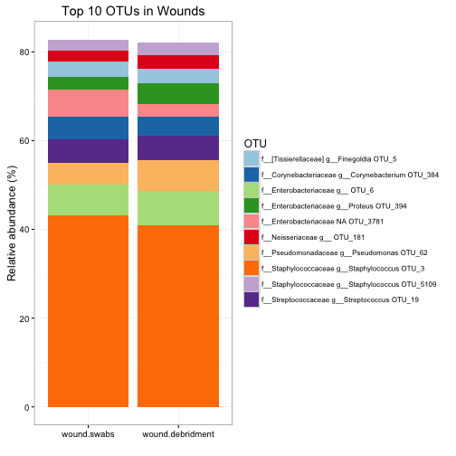

```r
#Now the top 10
top10wounds<-average_abund_wounds[1:10,]
top10wounds<-data.frame(top10wounds)
top10wounds<-cbind(top10wounds,tax_table(rare_mydata_sub)[rownames(top10wounds),])
top10wounds$OTU<-paste(top10wounds$Family, top10wounds$Genus,rownames(top10wounds))
top10wounds_melt<-top10wounds[,c(1,2,10)]
#Now melt data to the right format for ggplot
top10wounds_melt<-melt(top10wounds_melt)
#Now plot a stacked barplot
ggplot(top10wounds_melt, aes(x=variable, y=value, fill=OTU))+geom_bar(stat="identity")+ggtitle("Top 10 OTUs in Wounds")+labs(x = "", y="Relative abundance (%)")+ theme(legend.text = element_text(size = 8, ))+ scale_fill_brewer(palette="Paired")
```

Now per patient

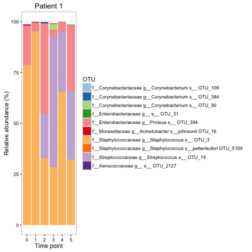

```r
#create vectors of sample names for wound swabs for each patient
P1sd<-sample_data(rare_mydata_sub)[sample_data(rare_mydata_sub)[,"subject"]=="P1"]
P1_wounds<-rownames(P1sd)[P1sd[,"sampletype2"]=="wound_swab"]
P2sd<-sample_data(rare_mydata_sub)[sample_data(rare_mydata_sub)[,"subject"]=="P2"]
P2_wounds<-rownames(P2sd)[P2sd[,"sampletype2"]=="wound_swab"]
P5sd<-sample_data(rare_mydata_sub)[sample_data(rare_mydata_sub)[,"subject"]=="P5"]
P5_wounds<-rownames(P5sd)[P5sd[,"sampletype2"]=="wound_swab"]
P6sd<-sample_data(rare_mydata_sub)[sample_data(rare_mydata_sub)[,"subject"]=="P6"]
P6_wounds<-rownames(P6sd)[P6sd[,"sampletype2"]=="wound_swab"]
P7sd<-sample_data(rare_mydata_sub)[sample_data(rare_mydata_sub)[,"subject"]=="P7"]
P7_wounds<-rownames(P7sd)[P7sd[,"sampletype2"]=="wound_swab"]
P8sd<-sample_data(rare_mydata_sub)[sample_data(rare_mydata_sub)[,"subject"]=="P8"]
P8_wounds<-rownames(P8sd)[P8sd[,"sampletype2"]=="wound_swab"]
P9sd<-sample_data(rare_mydata_sub)[sample_data(rare_mydata_sub)[,"subject"]=="P9"]
P9_wounds<-rownames(P9sd)[P9sd[,"sampletype2"]=="wound_swab"]
P10sd<-sample_data(rare_mydata_sub)[sample_data(rare_mydata_sub)[,"subject"]=="P10"]
P10_wounds<-rownames(P10sd)[P10sd[,"sampletype2"]=="wound_swab"]
#make otu table only for P1 wound swabs, and sort by rowsums.  Then convert counts to %, order columns by name, add taxonomy, bind to a single OTU columns with the numerical OTU identifier, subset to top ten and plot over time using ggplot.
P1_wounds_abund<-data.frame(otu_table(rare_mydata_sub)[,P1_wounds])
P1_wounds_abund<-P1_wounds_abund[order(-rowSums(P1_wounds_abund)),]
P1_wounds_abund<-(P1_wounds_abund/30000)*100
P1_wounds_abund<-P1_wounds_abund[,order(names(P1_wounds_abund))]
P1_wounds_abund<-cbind(P1_wounds_abund,tax_table(rare_mydata_sub)[rownames(P1_wounds_abund),c("Family","Genus","Species")])
P1_wounds_abund$OTU<-paste(P1_wounds_abund$Family,P1_wounds_abund$Genus,P1_wounds_abund$Species, rownames(P1_wounds_abund))
P1_wounds_abund<-P1_wounds_abund[,c(1,2,3,4,5,6,10)]
P1_wounds_top10<-P1_wounds_abund[1:10,]
colnames(P1_wounds_top10)<-c("0","1","2","3","4","5","OTU")
P1_wounds_top10<-melt(P1_wounds_top10)
#Now plot a stacked barplot
P1_wound_plot<-ggplot(P1_wounds_top10, aes(x=variable, y=value, fill=OTU))+geom_bar(stat="identity")+scale_fill_brewer(palette="Paired")+ggtitle("Patient 1")+ labs(x = "Time point", y="Relative abundance (%)")
P1_wound_plot
```

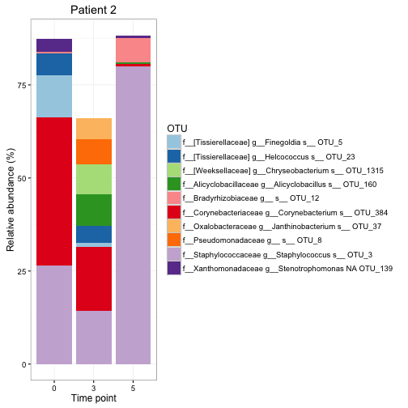

```r
#Still need to figure our best colour scale and labels - will do this later.
#Repeat for patient 2
P2_wounds_abund<-data.frame(otu_table(rare_mydata_sub)[,P2_wounds])
P2_wounds_abund<-P2_wounds_abund[order(-rowSums(P2_wounds_abund)),]
P2_wounds_abund<-(P2_wounds_abund/30000)*100
P2_wounds_abund<-P2_wounds_abund[,order(names(P2_wounds_abund))]
P2_wounds_abund<-cbind(P2_wounds_abund,tax_table(rare_mydata_sub)[rownames(P2_wounds_abund),c("Family","Genus","Species")])
P2_wounds_abund$OTU<-paste(P2_wounds_abund$Family,P2_wounds_abund$Genus,P2_wounds_abund$Species, rownames(P2_wounds_abund))
P2_wounds_abund<-P2_wounds_abund[,c(1,2,3,7)]
P2_wounds_top10<-P2_wounds_abund[1:10,]
colnames(P2_wounds_top10)<-c("0","3","5","OTU")
P2_wounds_top10<-melt(P2_wounds_top10)
#Now plot a stacked barplot
P2_wound_plot<-ggplot(P2_wounds_top10, aes(x=variable, y=value, fill=OTU))+geom_bar(stat="identity")+scale_fill_brewer(palette="Paired")+ggtitle("Patient 2")+ labs(x = "Time point", y="Relative abundance (%)")
P2_wound_plot
```

```r
#Now repeat for P5
P5_wounds_abund<-data.frame(otu_table(rare_mydata_sub)[,P5_wounds])
P5_wounds_abund<-P5_wounds_abund[order(-rowSums(P5_wounds_abund)),]
P5_wounds_abund<-(P5_wounds_abund/30000)*100
P5_wounds_abund<-P5_wounds_abund[,order(names(P5_wounds_abund))]
P5_wounds_abund<-cbind(P5_wounds_abund,tax_table(rare_mydata_sub)[rownames(P5_wounds_abund),c("Family","Genus","Species")])
P5_wounds_abund$OTU<-paste(P5_wounds_abund$Family,P5_wounds_abund$Genus,P5_wounds_abund$Species, rownames(P5_wounds_abund))
P5_wounds_abund<-P5_wounds_abund[,c(1,2,3,4,5,6,10)]
P5_wounds_top10<-P5_wounds_abund[1:10,]
colnames(P5_wounds_top10)<-c("0","1","2","3","4","5","OTU")
P5_wounds_top10<-melt(P5_wounds_top10)
```

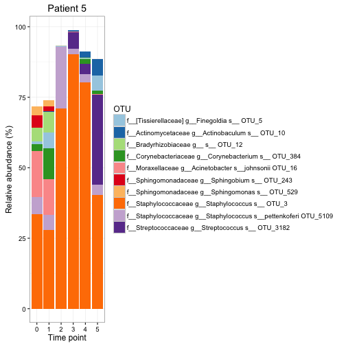

```r
#Now plot a stacked barplot
P5_wound_plot<-ggplot(P5_wounds_top10, aes(x=variable, y=value, fill=OTU))+geom_bar(stat="identity")+scale_fill_brewer(palette="Paired")+ggtitle("Patient 5")+ labs(x = "Time point", y="Relative abundance (%)")
P5_wound_plot
```

```r
#Repeat for P6
P6_wounds_abund<-data.frame(otu_table(rare_mydata_sub)[,P6_wounds])
P6_wounds_abund<-P6_wounds_abund[order(-rowSums(P6_wounds_abund)),]
P6_wounds_abund<-(P6_wounds_abund/30000)*100
P6_wounds_abund<-P6_wounds_abund[,order(names(P6_wounds_abund))]
P6_wounds_abund<-cbind(P6_wounds_abund,tax_table(rare_mydata_sub)[rownames(P6_wounds_abund),c("Family","Genus","Species")])
P6_wounds_abund$OTU<-paste(P6_wounds_abund$Family,P6_wounds_abund$Genus,P6_wounds_abund$Species, rownames(P6_wounds_abund))
P6_wounds_abund<-P6_wounds_abund[,c(1,2,3,4,5,9)]
P6_wounds_top10<-P6_wounds_abund[1:10,]
colnames(P6_wounds_top10)<-c("0","1","2","3","4","OTU")
P6_wounds_top10<-melt(P6_wounds_top10)
```

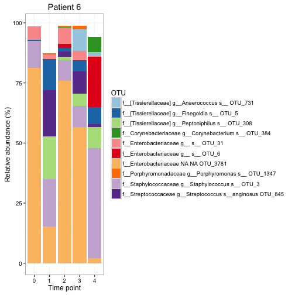

```r
#Now plot a stacked barplot
P6_wound_plot<-ggplot(P6_wounds_top10, aes(x=variable, y=value, fill=OTU))+geom_bar(stat="identity")+scale_fill_brewer(palette="Paired")+ggtitle("Patient 6")+ labs(x = "Time point", y="Relative abundance (%)")
P6_wound_plot
```

```r
#Repeat for P7
P7_wounds_abund<-data.frame(otu_table(rare_mydata_sub)[,P7_wounds])
P7_wounds_abund<-P7_wounds_abund[order(-rowSums(P7_wounds_abund)),]
P7_wounds_abund<-(P7_wounds_abund/30000)*100
P7_wounds_abund<-P7_wounds_abund[,order(names(P7_wounds_abund))]
P7_wounds_abund<-cbind(P7_wounds_abund,tax_table(rare_mydata_sub)[rownames(P7_wounds_abund),c("Family","Genus","Species")])
P7_wounds_abund$OTU<-paste(P7_wounds_abund$Family,P7_wounds_abund$Genus,P7_wounds_abund$Species, rownames(P7_wounds_abund))
P7_wounds_abund<-P7_wounds_abund[,c(1,2,3,4,8)]
P7_wounds_top10<-P7_wounds_abund[1:10,]
colnames(P7_wounds_top10)<-c("0","1","2","3","OTU")
P7_wounds_top10<-melt(P7_wounds_top10)
```

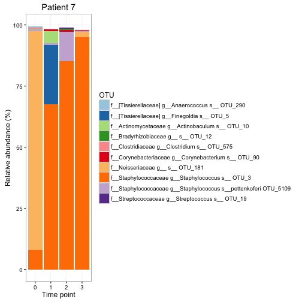

```r
#Now plot a stacked barplot
P7_wound_plot<-ggplot(P7_wounds_top10, aes(x=variable, y=value, fill=OTU))+geom_bar(stat="identity")+scale_fill_brewer(palette="Paired")+ggtitle("Patient 7")+ labs(x = "Time point", y="Relative abundance (%)")
P7_wound_plot
```

```r
#Repeat for P8
P8_wounds_abund<-data.frame(otu_table(rare_mydata_sub)[,P8_wounds])
P8_wounds_abund<-P8_wounds_abund[order(-rowSums(P8_wounds_abund)),]
P8_wounds_abund<-(P8_wounds_abund/30000)*100
P8_wounds_abund<-P8_wounds_abund[,order(names(P8_wounds_abund))]
P8_wounds_abund<-cbind(P8_wounds_abund,tax_table(rare_mydata_sub)[rownames(P8_wounds_abund),c("Family","Genus","Species")])
P8_wounds_abund$OTU<-paste(P8_wounds_abund$Family,P8_wounds_abund$Genus,P8_wounds_abund$Species, rownames(P8_wounds_abund))
P8_wounds_abund<-P8_wounds_abund[,c(1,2,3,4,5,9)]
P8_wounds_top10<-P8_wounds_abund[1:10,]
colnames(P8_wounds_top10)<-c("0","1","2","3","5","OTU")
P8_wounds_top10<-melt(P8_wounds_top10)
```

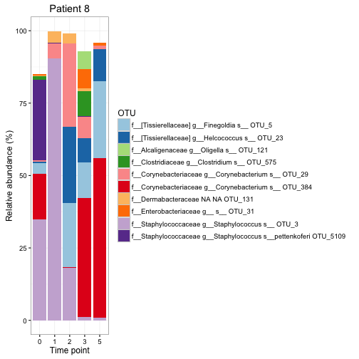

```r
#Now plot a stacked barplot
P8_wound_plot<-ggplot(P8_wounds_top10, aes(x=variable, y=value, fill=OTU))+geom_bar(stat="identity")+scale_fill_brewer(palette="Paired")+ labs(x = "Time point", y="Relative abundance (%)")+ggtitle("Patient 8")
P8_wound_plot
```

```r
#Repeat for P9
P9_wounds_abund<-data.frame(otu_table(rare_mydata_sub)[,P9_wounds])
P9_wounds_abund<-P9_wounds_abund[order(-rowSums(P9_wounds_abund)),]
P9_wounds_abund<-(P9_wounds_abund/30000)*100
P9_wounds_abund<-P9_wounds_abund[,order(names(P9_wounds_abund))]
P9_wounds_abund<-cbind(P9_wounds_abund,tax_table(rare_mydata_sub)[rownames(P9_wounds_abund),c("Family","Genus","Species")])
P9_wounds_abund$OTU<-paste(P9_wounds_abund$Family,P9_wounds_abund$Genus,P9_wounds_abund$Species, rownames(P9_wounds_abund))
P9_wounds_abund<-P9_wounds_abund[,c(1,2,3,4,5,9)]
P9_wounds_top10<-P9_wounds_abund[1:10,]
colnames(P9_wounds_top10)<-c("0","1","2","4","5","OTU")
P9_wounds_top10<-melt(P9_wounds_top10)
```

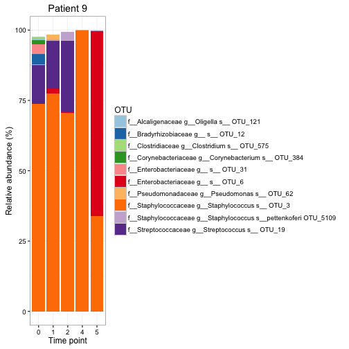

```r
#Now plot a stacked barplot
P9_wound_plot<-ggplot(P9_wounds_top10, aes(x=variable, y=value, fill=OTU))+geom_bar(stat="identity")+scale_fill_brewer(palette="Paired")+ labs(x = "Time point", y="Relative abundance (%)")+ggtitle("Patient 9")
P9_wound_plot
```

```r
#Repeat for P10
P10_wounds_abund<-data.frame(otu_table(rare_mydata_sub)[,P10_wounds])
P10_wounds_abund<-P10_wounds_abund[order(-rowSums(P10_wounds_abund)),]
P10_wounds_abund<-(P10_wounds_abund/30000)*100
P10_wounds_abund<-P10_wounds_abund[,order(names(P10_wounds_abund))]
P10_wounds_abund<-cbind(P10_wounds_abund,tax_table(rare_mydata_sub)[rownames(P10_wounds_abund),c("Family","Genus","Species")])
P10_wounds_abund$OTU<-paste(P10_wounds_abund$Family,P10_wounds_abund$Genus,P10_wounds_abund$Species, rownames(P10_wounds_abund))
P10_wounds_abund<-P10_wounds_abund[,c(1,2,3,4,5,9)]
P10_wounds_top10<-P10_wounds_abund[1:10,]
colnames(P10_wounds_top10)<-c("0","1","2","3","4","OTU")
P10_wounds_top10<-melt(P10_wounds_top10)
```

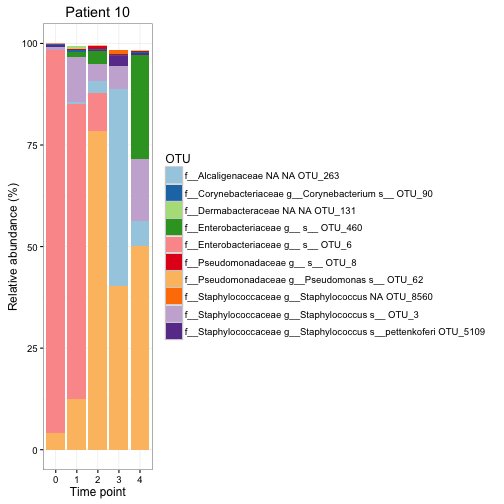

```r
#Now plot a stacked barplot
P10_wound_plot<-ggplot(P10_wounds_top10, aes(x=variable, y=value, fill=OTU))+geom_bar(stat="identity")+scale_fill_brewer(palette="Paired")+ labs(x = "Time point", y="Relative abundance (%)")+ggtitle("Patient 10")
P10_wound_plot
```

```r
diaball_dist<-phyloseq::distance(rare_mydata_sub, method="unifrac", type="samples", weighted=TRUE)
diaball_ord<-ordinate(rare_mydata_sub, method="PCoA", distance="diaball_dist", type="samples")
```

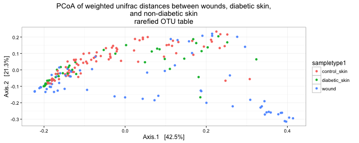

```r
plot_ordination(rare_mydata_sub, diaball_ord, type="samples", color="sampletype1", title="PCoA of weighted unifrac distances between wounds, diabetic skin,\nand non-diabetic skin\nrarefied OTU table")
```

[output not shown]

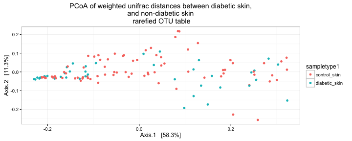

```r
plot_ordination(rare_skin, rare_skin_ord, type="samples", color="sampletype1", title="PCoA of weighted unifrac distances between diabetic skin,\nand non-diabetic skin\n rarefied OTU table")
```

#

```
{r}
#rare_skin_dist_jc<-phyloseq::distance(rare_skin, method="jaccard", type="samples")
#rare_skin_ord_jc<-ordinate(rare_skin, method="PCoA", distance="rare_skin_dist_jc", type="samples")
#
```

#

```
{r fig.width=10, fig.height=4}
#plot_ordination(rare_skin, rare_skin_ord_jc, type="samples", color="sampletype1", title="PCoA of Jaccard distances between diabetic skin,\nand non-diabetic skin\n rarefied OTU table")
#
```

#Try Horn-Morista #

```
{r}
#diaball_dist_hm <-phyloseq::distance(rare_mydata_sub, method="horn", type="samples")
#diaball_ord_hm <- ordinate(rare_mydata_sub, method="PCoA", distance="diaball_dist_hm", type="samples")
#
```

#

```
{r fig.width=10, fig.height=4}
#plot_ordination(rare_mydata_sub, diaball_ord_hm, type="samples", color="sampletype1", title="PCoA of Horn-Morista distances between wounds, diabetic skin,\nand non-diabetic skin\n rarefied OTU table")
#
```

#

```
{r}
#rare_skin_dist_hm<-phyloseq::distance(rare_skin, method="horn", type="samples")
#rare_skin_ord_hm<-ordinate(rare_skin, method="PCoA", distance="rare_skin_dis#t_hm", type="samples")
#
```

#

```
{r fig.width=10, fig.height=4}
#plot_ordination(rare_skin, rare_skin_ord_hm, type="samples", color="sampletype1", title="PCoA of Horn-Morista distances between diabetic skin,\nand non-diabetic skin\n rarefied OTU table")
#plot_ordination(rare_skin, rare_skin_ord_hm, type="samples", color="subject", shape="sampletype1", title="PCoA of Horn-Morista distances between diabetic skin,\nand non-diabetic skin\n rarefied OTU table")
#
```

Permanova tests for signficance on rarefied otu distance analysis

```r
#PERMANOVA-create a file of factors for only the samples in the analysis
mapping<- sample_data(rare_skin)
health<- mapping$health
subject<- mapping$subject
#PERMANOVA analysis
library("vegan")
perm_rare_unifrac<-adonis(rare_skin_dist ~ health/subject, data=as(sample_data(rare_skin),"data.frame"))
perm_rare_unifrac
```

```
##
## Call:
## adonis(formula = rare_skin_dist ~ health/subject, data = as(sample_data(rare_skin),      "data.frame"))
##
## Permutation: free
## Number of permutations: 999
##
## Terms added sequentially (first to last)
##
##                 Df SumsOfSqs  MeanSqs F.Model     R2 Pr(>F)
## health           1    0.1329 0.132867  3.8030 0.0232  0.019 *
## health:subject  14    1.8912 0.135087  3.8665 0.3302  0.001 ***
## Residuals      106    3.7034 0.034938         0.6466
## Total          121    5.7275                  1.0000
## ---
## Signif. codes:  0 '***' 0.001 '**' 0.01 '*' 0.05 '.' 0.1 ' ' 1
```

```r
#perm_rare_jaccard<-adonis(rare_skin_dist_jc ~ health/subject, data=as(sample_data(rare_skin),"data.frame"))
#perm_rare_jaccard
#perm_rare_hm<-adonis(rare_skin_dist_hm ~ health/subject, data=as(sample_data(rare_skin),"data.frame"))
#perm_rare_hm
```

Variance Stabilizing Transformation

```r
library("DESeq2")
diaball_dds <- phyloseq_to_deseq2(mydata_sub, ~1)
#Filter OTUs present in only one sample
#What about otus present in less than 10% of samples?
diaball_filtered_dds <- diaball_dds[ rowSums(counts(diaball_dds)) > 1, ]
#estaimte size factors and dispersion in DESeq2
diaball_filtered_dds <- estimateSizeFactors(diaball_filtered_dds)
diaball_filtered_dds <- estimateDispersions(diaball_filtered_dds, fitType = "local")
#Create new phyloseq object from mydata_sub and populate the otu table with the vst values
diaball_vst <-mydata_sub
otu_table(diaball_vst)<- otu_table(getVarianceStabilizedData(diaball_filtered_dds), taxa_are_rows = TRUE)
#Remove -ive values in matrix, replace with 0
matrix_vst_otu <- otu_table(diaball_vst, taxa_are_rows=TRUE)
matrix_vst_otu[matrix_vst_otu<0]=0
otu_table(diaball_vst)<-otu_table(matrix_vst_otu, taxa_are_rows=TRUE)
```

Weighted unifrac and ordination

```r
diaball_vst_dist<-phyloseq::distance(diaball_vst, method="unifrac", type="samples", weighted=TRUE)
diaball_vst_ord<-ordinate(diaball_vst, method="PCoA", distance="diaball_vst_dist", type="samples")
```

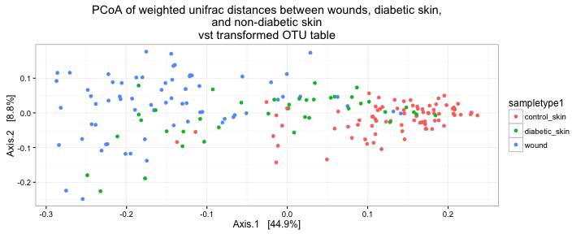

```r
plot_ordination(diaball_vst, diaball_vst_ord, type="samples", color="sampletype1", title="PCoA of weighted unifrac distances between wounds, diabetic skin,\nand non-diabetic skin\nvst transformed OTU table")
```

```r
#subset to skin only and repeat
skin_vst<-subset_samples(diaball_vst, sampletype1%in%c("control_skin", "diabetic_skin"))
skin_vst_dist<-phyloseq::distance(skin_vst, method="unifrac", type="samples", weighted=TRUE)
skin_vst_ord<-phyloseq::ordinate(skin_vst, method="PCoA", distance="skin_vst_dist")
```

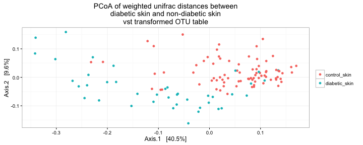

```r
plot_ordination(skin_vst, skin_vst_ord, type="samples", color="sampletype1", title="PCoA of weighted unifrac distances between\ndiabetic skin and non-diabetic skin\nvst transformed OTU table")+theme(legend.title=element_blank())
```

```r
Figure4<-plot_ordination(skin_vst, skin_vst_ord, type="samples", color="sampletype1", title="PCoA of weighted unifrac distances between\ndiabetic skin and non-diabetic skin")+theme(legend.title=element_blank())
####Trying to put 95% confidence interval elipses on plot using instructions from here https://www.biostars.org/p/126454/, but can't get it to work - works on CCA plots but not Unifrac PCoA plots according to the example..
#Get data from plot
#skin_vst_ord_data<-(plot_ordination(skin_vst, skin_vst_ord, type="samples", color="sampletype1", title="PCoA of weighted unifrac distances between\ndiabetic skin and non-diabetic skin\nvst transformed OTU table"))$data
#skin_vst_ord_data
# add a fake variable to the experiment
#sample_data(skin_vst)$fake <- 1:nsamples(skin_vst)
# use the envfit function of vegan
#ord_ef_skin_vst <- envfit(skin_vst_ord ~ fake,permu=1000,data = as(sample_data(skin_vst),"data.frame"))
```

#Use Jaccard and Horn-Morista distances #

```
{r}
#diaball_vst_dist_jc<-phyloseq::distance(diaball_vst, method="jaccard", type="samples")
#diaball_vst_ord_jc<-ordinate(diaball_vst, method="PCoA", distance="diaball_vst_dist_jc", type="samples")
#
```

#

```
{r fig.width=10, fig.height=4}
#plot_ordination(diaball_vst, diaball_vst_ord_jc, type="samples", color="sampletype1", title="PCoA of Jaccard distances between wounds, diabetic skin,\nand non-diabetic skin\nvst transformed OTU table")
#
```

#

```
{r}
#repeat on skin only subset
#skin_vst_dist_jc<-phyloseq::distance(skin_vst, method="jaccard", type="samples")
#skin_vst_ord_jc<-phyloseq::ordinate(skin_vst, method="PCoA", distance#="skin_vst_dist_jc")
#
```

#

```
{r fig.width=10, fig.height=4}
#plot_ordination(skin_vst, skin_vst_ord_jc, type="samples", color="sampletype1", title="PCoA of Jaccard distances between\ndiabetic skin and non-diabetic skin\nvst transformed OTU table")
#
```

#

```
{r}
#diaball_dist_hm<-phyloseq::distance(diaball_vst, method="horn", type="samples")
#diaball_ord_hm<-ordinate(diaball_vst, method="PCoA", distance="diaball_dist_hm", type="samples")
#
```

```r
perm_vst_unifrac<-adonis(skin_vst_dist ~ health/subject, data=as(sample_data(skin_vst),"data.frame"))
perm_vst_unifrac
```

```
##
## Call:
## adonis(formula = skin_vst_dist ~ health/subject, data = as(sample_data(skin_vst),      "data.frame"))
##
## Permutation: free
## Number of permutations: 999
##
## Terms added sequentially (first to last)
##
##                 Df SumsOfSqs MeanSqs F.Model      R2 Pr(>F)
## health           1    0.7004 0.70044 31.5927 0.15486  0.001 ***
## health:subject  14    1.4724 0.10517  4.7438 0.32555  0.001 ***
## Residuals      106    2.3501 0.02217         0.51959
## Total          121    4.5230                 1.00000
## ---
## Signif. codes:  0 '***' 0.001 '**' 0.01 '*' 0.05 '.' 0.1 ' ' 1
```

```r
#perm_vst_jc<-adonis(skin_vst_dist_jc ~ health/subject, data=as(sample_data(skin_vst),"data.frame"))
#perm_vst_jc
#perm_vst_hm<-adonis(skin_vst_dist_hm ~ health/subject, data=as(sample_data(skin_vst),"data.frame"))
#perm_vst_hm
```

Differential abundance analysis using DESeq2 This analysis uses raw counts… does not do a vst on the data, but does other data transformation to account for differences in library size and to stabilise variance within groups.

```r
#Subset raw count data to skin only
mydata_sub_skin<-subset_samples(mydata_sub, sampletype1%in%c("control_skin","diabetic_skin"))
#Filter OTUs seen less than 3 times in less than 20% of samples
mydata_sub_skin_filter<-filter_taxa(mydata_sub_skin, function(x) sum(x > 3) > (0.2*length(x)), TRUE)
#convert to DESeq2 object and specify experimental design
skin_diff_dds<-phyloseq_to_deseq2(mydata_sub_skin_filter, ~ health + health:subject2, ignoreRank=TRUE)
#manually creating the coldata file to manually create the model matrix
write.csv(sample_data(mydata_sub_skin_filter),file="r_data/coldata.csv")
coldata <- read.csv("r_data/coldata.csv")
head(coldata)
```

```
##          X X.SampleID BarcodeSequence LinkerPrimerSequence run_prefix
## 1  CP7_3_L    CP7_3_L              NA                   NA    CP7_3_L
## 2  P7_1_SC    P7_1_SC              NA                   NA    P7_1_SC
## 3      CP7        CP7              NA                   NA     CP7_1R
## 4  P9_4_SC    P9_4_SC              NA                   NA    P9_4_SC
## 5  CP6_2_R    CP6_2_R              NA                   NA    CP6_2_R
## 6 P10_1_SC   P10_1_SC              NA                   NA   P10_1_SC
##     health   sampletype1          sampletype2 time subject subject2
## 1  control  control_skin    control_skin_left    3     CP7        g
## 2 diabetes diabetic_skin diabetic_skin_contra    1      P7        e
## 3  control  control_skin   control_skin_right    1     CP7        g
## 4 diabetes diabetic_skin diabetic_skin_contra    4      P9        g
## 5  control  control_skin   control_skin_right    2     CP6        f
## 6 diabetes diabetic_skin diabetic_skin_contra    1     P10        h
##   woundstatus primer_barcodes Description
## 1          NA         F20_R25     control
## 2          NA          F20_R7    diabetes
## 3          NA           F9_R8     control
## 4          NA          F3_R16    diabetes
## 5          NA          F16_R9     control
## 6          NA          F2_R17    diabetes
```

```r
#The specified model creates issues with some columns of the model matrix having only 0.  Creating the model matrix manually and removing the columns with only 0 as specified in the DESeq2 vignette 3.12.2
m1 <- model.matrix(~ health + subject2:health, coldata)
colnames(m1)
```

```
##  [1] "(Intercept)"              "healthdiabetes"
##  [3] "healthcontrol:subject2b"  "healthdiabetes:subject2b"
##  [5] "healthcontrol:subject2c"  "healthdiabetes:subject2c"
##  [7] "healthcontrol:subject2d"  "healthdiabetes:subject2d"
##  [9] "healthcontrol:subject2e"  "healthdiabetes:subject2e"
## [11] "healthcontrol:subject2f"  "healthdiabetes:subject2f"
## [13] "healthcontrol:subject2g"  "healthdiabetes:subject2g"
## [15] "healthcontrol:subject2h"  "healthdiabetes:subject2h"
## [17] "healthcontrol:subject2i"  "healthdiabetes:subject2i"
```

```r
#unname(m1)
m1 <- m1[,-18]
#unname(m1)
m1 <- m1[,-15]
#unname(m1)
#Make sure log2 abundance differences are calculated compared to the control
skin_diff_dds$health <- relevel(skin_diff_dds$health, "control")
#Do diferential abundance analysis on diabetic vs control skin adding the custom matrix generated above using the argument "full".
skin_diff_dds<-DESeq(skin_diff_dds, full=m1, betaPrior=FALSE)
```

```
## using supplied model matrix
## using supplied model matrix
## using supplied model matrix
## -- replacing outliers and refitting for 5 genes
## -- DESeq argument 'minReplicatesForReplace' = 7
## -- original counts are preserved in counts(dds)
## using supplied model matrix
## using supplied model matrix
## using supplied model matrix
```

```r
#Get results, order by p value, then create a matrix with only sig p value results and merge with the names of the taxa for each OTU.
res_skin <- results(skin_diff_dds, alpha=0.05, lfcThreshold = 1)
summary(res_skin, alpha=0.05)
```

```
##
## out of 612 with nonzero total read count
## adjusted p-value < 0.05
## LFC > 0 (up)     : 50, 8.2%
## LFC < 0 (down)   : 42, 6.9%
## outliers [1]     : 3, 0.49%
## low counts [2]   : 31, 5.1%
## (mean count < 3.7)
## [1] see 'cooksCutoff' argument of ?results
## [2] see 'independentFiltering' argument of ?results
```

```r
sig_num<-sum(res_skin$padj < 0.05, na.rm=TRUE)
resOrdered_skin <- res_skin[order(res_skin$padj),]
skin_sig <- resOrdered_skin[1:sig_num,]
df_skin_sig<-data.frame(skin_sig)
res_Ordered_skin_rownames <- row.names(skin_sig)
skin_res_names <- tax_table(mydata_sub_skin)[res_Ordered_skin_rownames,]
skin_diff_merge <-merge(skin_res_names, skin_sig, by="row.names")
skin_diff_merge[1:10,]
```

```
##    Row.names      Domain            Phylum                  Class
## 1   OTU_1005 k__Bacteria       p__[Thermi]          c__Deinococci
## 2   OTU_1013 k__Bacteria p__Proteobacteria c__Alphaproteobacteria
## 3   OTU_1032 k__Bacteria  p__Cyanobacteria         c__Chloroplast
## 4    OTU_108 k__Bacteria p__Actinobacteria      c__Actinobacteria
## 5   OTU_1094 k__Bacteria p__Actinobacteria      c__Actinobacteria
## 6   OTU_1096 k__Bacteria p__Proteobacteria c__Alphaproteobacteria
## 7   OTU_1097 k__Bacteria p__Proteobacteria c__Alphaproteobacteria
## 8   OTU_1142 k__Bacteria p__Proteobacteria c__Alphaproteobacteria
## 9   OTU_1195 k__Bacteria p__Proteobacteria c__Alphaproteobacteria
## 10  OTU_1198 k__Bacteria  p__Cyanobacteria    c__Nostocophycideae
##                  Order                 Family               Genus Species
## 1     o__Deinococcales      f__Deinococcaceae      g__Deinococcus     s__
## 2   o__Rhodobacterales    f__Rhodobacteraceae g__Rubellimicrobium     s__
## 3      o__Streptophyta                    f__                 g__     s__
```

[output cut: 18 more lines]

```r
skin_diff_merge<-skin_diff_merge[order(skin_diff_merge$padj),]
skin_diff_merge[1:10,]
```

```
##    Row.names      Domain            Phylum                  Class
## 4    OTU_108 k__Bacteria p__Actinobacteria      c__Actinobacteria
## 20   OTU_146 k__Bacteria p__Actinobacteria      c__Actinobacteria
## 25  OTU_1606 k__Bacteria p__Proteobacteria c__Alphaproteobacteria
## 41    OTU_24 k__Bacteria p__Actinobacteria      c__Actinobacteria
## 40  OTU_2375 k__Bacteria p__Actinobacteria      c__Actinobacteria
## 53  OTU_3816 k__Bacteria     p__Firmicutes             c__Bacilli
## 24  OTU_1589 k__Bacteria p__Actinobacteria      c__Actinobacteria
## 66   OTU_465 k__Bacteria  p__Bacteroidetes      c__Flavobacteriia
## 30    OTU_18 k__Bacteria p__Proteobacteria c__Alphaproteobacteria
## 37  OTU_2215 k__Bacteria       p__[Thermi]          c__Deinococci
##                   Order                 Family               Genus
## 4    o__Actinomycetales  f__Corynebacteriaceae  g__Corynebacterium
## 20   o__Actinomycetales                   <NA>                <NA>
## 25   o__Rhodobacterales    f__Rhodobacteraceae g__Rubellimicrobium
```

[output cut: 29 more lines]

```r
#Make the column Row.Names the actual row names
row.names(skin_diff_merge)<- skin_diff_merge[,1]
skin_diff_merge[,1]<-NULL
#Order sig results by log2FoldChange
skin_diff_merge_fco <- skin_diff_merge[order(-skin_diff_merge$log2FoldChange),]
skin_diff_merge_fco[1:10,]
```

```
##               Domain            Phylum                    Class
## OTU_3816 k__Bacteria     p__Firmicutes               c__Bacilli
## OTU_1589 k__Bacteria p__Actinobacteria        c__Actinobacteria
## OTU_669  k__Bacteria       p__[Thermi]            c__Deinococci
## OTU_1005 k__Bacteria       p__[Thermi]            c__Deinococci
## OTU_4961 k__Bacteria p__Proteobacteria   c__Alphaproteobacteria
## OTU_825  k__Bacteria p__Proteobacteria   c__Alphaproteobacteria
## OTU_7964 k__Bacteria p__Actinobacteria        c__Actinobacteria
## OTU_1269 k__Bacteria       p__[Thermi]            c__Deinococci
## OTU_352  k__Bacteria p__Proteobacteria   c__Alphaproteobacteria
## OTU_1413 k__Bacteria  p__Cyanobacteria c__Oscillatoriophycideae
##                         Order                Family            Genus
## OTU_3816   o__Lactobacillales   f__Lactobacillaceae g__Lactobacillus
## OTU_1589 o__Bifidobacteriales f__Bifidobacteriaceae             <NA>
## OTU_669      o__Deinococcales     f__Deinococcaceae   g__Deinococcus
## OTU_1005     o__Deinococcales     f__Deinococcaceae   g__Deinococcus
## OTU_4961  o__Rhodospirillales   f__Acetobacteraceae              g__
## OTU_825   o__Rhodospirillales   f__Acetobacteraceae              g__
## OTU_7964   o__Actinomycetales    f__Kineosporiaceae              g__
## OTU_1269     o__Deinococcales     f__Deinococcaceae   g__Deinococcus
## OTU_352      o__Rickettsiales     f__Rickettsiaceae    g__Rickettsia
## OTU_1413     o__Chroococcales      f__Xenococcaceae              g__
##           Species  baseMean log2FoldChange    lfcSE     stat       pvalue
## OTU_3816 s__iners 40.765894      12.563169 1.640400 7.048994 1.802159e-12
## OTU_1589     <NA> 25.161120      12.453327 1.690024 6.777018 1.226813e-11
## OTU_669       s__ 22.688792      12.232643 1.905854 5.893759 3.775085e-09
## OTU_1005      s__ 13.157950      10.778657 1.704266 5.737753 9.594111e-09
## OTU_4961      s__  8.178812      10.194312 1.711819 5.371079 7.826700e-08
## OTU_825       s__  5.422764       9.236270 1.724777 4.775267 1.794689e-06
## OTU_7964      s__  4.271141       8.745900 1.696338 4.566249 4.965297e-06
## OTU_1269      s__ 23.931418       8.726552 1.438440 5.371480 7.809302e-08
## OTU_352       s__ 11.490935       8.439749 1.785515 4.166724 3.090084e-05
## OTU_1413      s__  3.895789       8.368295 1.815994 4.057446 4.961237e-05
##                  padj
## OTU_3816 1.736080e-10
## OTU_1589 1.012997e-09
## OTU_669  1.818332e-07
## OTU_1005 4.265689e-07
## OTU_4961 2.261916e-06
## OTU_825  4.322210e-05
## OTU_7964 1.035112e-04
## OTU_1269 2.261916e-06
## OTU_352  5.103053e-04
## OTU_1413 7.168987e-04
```

Plot diff abund OTU counts for top 5 log2FC

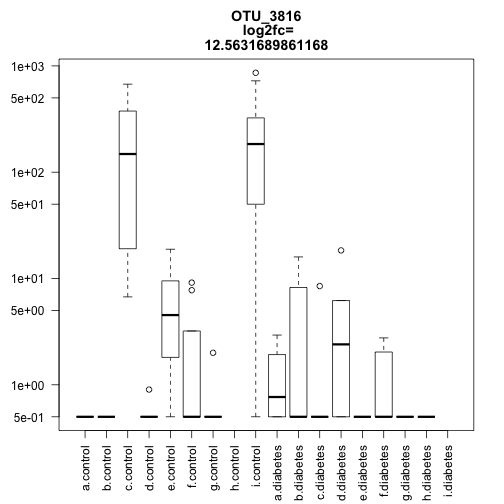

```r
#make health a factor for plotting
health<- mapping$health
log2FC_1<-plotCounts(skin_diff_dds, gene=row.names(skin_diff_merge_fco)[1], intgroup=c("health","subject2"), returnData=TRUE)
#alternative ggplot way of plotting the data is commented out below
#log2FC_1$subject2health <- interaction(log2FC_1$subject2, log2FC_1$health)
#ggplot(aes(y = count, x = subject2health), data = log2FC_1) + geom_boxplot() #+ scale_y_log10()
boxplot(log2FC_1$count ~ log2FC_1$subject2*log2FC_1$health, log="y", las=2, main=c(row.names(skin_diff_merge_fco)[1]," log2fc=",skin_diff_merge_fco$log2FoldChange[1]))
```

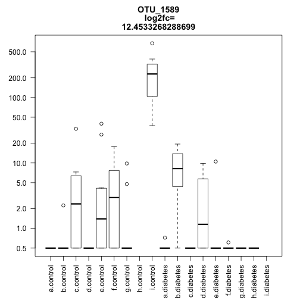

```r
log2FC_2<-plotCounts(skin_diff_dds, gene=row.names(skin_diff_merge_fco)[2], intgroup=c("health","subject2"), returnData=TRUE)
boxplot(log2FC_2$count ~ log2FC_2$subject2*log2FC_2$health, log="y", las=2, main=c(row.names(skin_diff_merge_fco)[2]," log2fc=",skin_diff_merge_fco$log2FoldChange[2]))
```

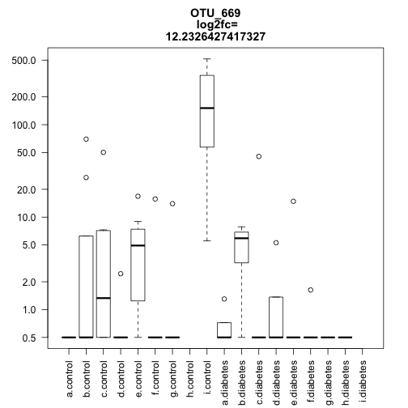

```r
log2FC_3<-plotCounts(skin_diff_dds, gene=row.names(skin_diff_merge_fco)[3], intgroup=c("health","subject2"), returnData=TRUE)
boxplot(log2FC_3$count ~ log2FC_3$subject2*log2FC_3$health, log="y", las=2, main=c(row.names(skin_diff_merge_fco)[3]," log2fc=",skin_diff_merge_fco$log2FoldChange[3]))
```

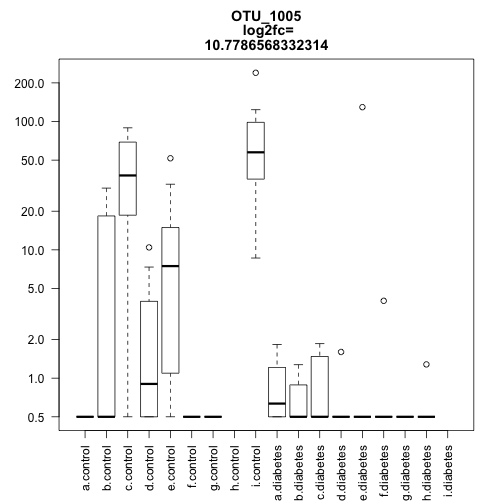

```r
log2FC_4<-plotCounts(skin_diff_dds, gene=row.names(skin_diff_merge_fco)[4], intgroup=c("health","subject2"), returnData=TRUE)
boxplot(log2FC_4$count ~ log2FC_4$subject2*log2FC_4$health, log="y", las=2, main=c(row.names(skin_diff_merge_fco)[4]," log2fc=",skin_diff_merge_fco$log2FoldChange[4]))
```

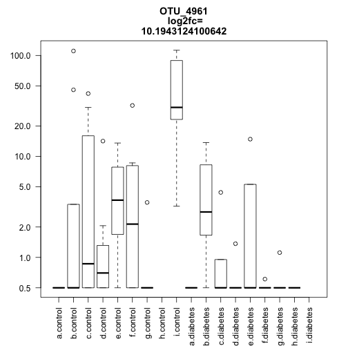

```r
log2FC_5<-plotCounts(skin_diff_dds, gene=row.names(skin_diff_merge_fco)[5], intgroup=c("health","subject2"), returnData=TRUE)
boxplot(log2FC_5$count ~ log2FC_5$subject2*log2FC_5$health, log="y", las=2, main=c(row.names(skin_diff_merge_fco)[5]," log2fc=",skin_diff_merge_fco$log2FoldChange[5]))
```

```r
log2FC_115<-plotCounts(skin_diff_dds, gene=row.names(skin_diff_merge_fco)[115], intgroup=c("health","subject2"), returnData=TRUE)
```

```
## Error in counts(dds, normalized = normalized, replaced = replaced)[gene, : subscript out of bounds
```

```r
boxplot(log2FC_115$count ~ log2FC_115$subject2*log2FC_115$health, log="y", las=2, main=c(row.names(skin_diff_merge_fco)[115]," log2fc=",skin_diff_merge_fco$log2FoldChange[115]))
```

```
## Error in eval(expr, envir, enclos): object 'log2FC_115' not found
```

Plot counts for top 5 by p value

```r
resOrdered_skin <- res_skin[order(res_skin$padj),]
resOrdered_skin[1:10,]
```

```
## log2 fold change (MLE): healthcontrol.subject2i
## Wald test p-value: healthcontrol.subject2i
## DataFrame with 10 rows and 6 columns
##           baseMean log2FoldChange     lfcSE      stat       pvalue
##          <numeric>      <numeric> <numeric> <numeric>    <numeric>
## OTU_108  339.81195     -10.938876 1.1101810 -8.952482 3.475762e-19
## OTU_146  377.50122      -7.097079 0.8090235 -7.536344 4.833314e-14
## OTU_1606  67.75907       7.785623 0.9079833  7.473291 7.821364e-14
## OTU_24   305.18523      -6.266504 0.7368372 -7.147446 8.840747e-13
## OTU_2375 413.48937      -8.827616 1.1074885 -7.067898 1.572980e-12
## OTU_3816  40.76589      12.563169 1.6403999  7.048994 1.802159e-12
## OTU_1589  25.16112      12.453327 1.6900245  6.777018 1.226813e-11
## OTU_465   63.31035      -8.150457 1.0998988 -6.501013 7.978071e-11
## OTU_18    37.29814       5.598765 0.7357129  6.250761 4.084577e-10
## OTU_2215  29.81910       7.614569 1.0662563  6.203545 5.520518e-10
##                  padj
##             <numeric>
## OTU_108  2.008991e-16
## OTU_146  1.396828e-11
## OTU_1606 1.506916e-11
## OTU_24   1.277488e-10
## OTU_2375 1.736080e-10
## OTU_3816 1.736080e-10
## OTU_1589 1.012997e-09
## OTU_465  5.764156e-09
## OTU_18   2.623206e-08
## OTU_2215 3.190860e-08
```

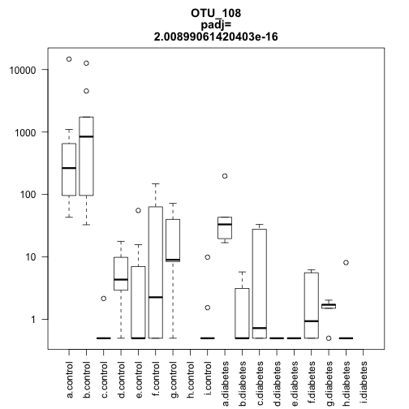

```r
padj_1<-plotCounts(skin_diff_dds, gene=row.names(resOrdered_skin)[1], intgroup=c("health","subject2"), returnData=TRUE)
boxplot(padj_1$count ~ padj_1$subject2*padj_1$health, log="y", las=2, main=c(row.names(resOrdered_skin)[1]," padj= ", resOrdered_skin$padj[1]))
```

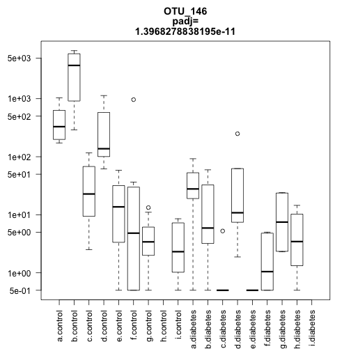

```r
padj_2<-plotCounts(skin_diff_dds, gene=row.names(resOrdered_skin)[2], intgroup=c("health","subject2"), returnData=TRUE)
boxplot(padj_2$count ~ padj_2$subject2*padj_2$health, log="y", las=2, main=c(row.names(resOrdered_skin)[2]," padj= ", resOrdered_skin$padj[2]))
```

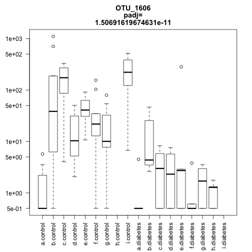

```r
padj_3<-plotCounts(skin_diff_dds, gene=row.names(resOrdered_skin)[3], intgroup=c("health","subject2"), returnData=TRUE)
boxplot(padj_3$count ~ padj_3$subject2*padj_3$health, log="y", las=2, main=c(row.names(resOrdered_skin)[3]," padj= ", resOrdered_skin$padj[3]))
```

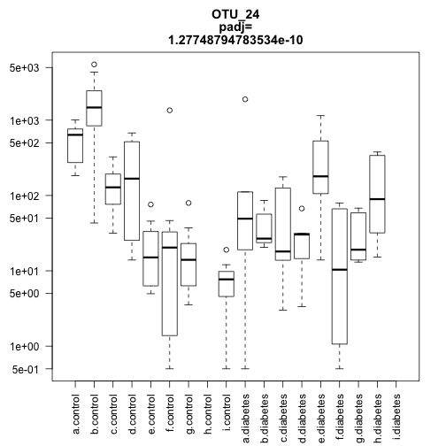

```r
padj_4<-plotCounts(skin_diff_dds, gene=row.names(resOrdered_skin)[4], intgroup=c("health","subject2"), returnData=TRUE)
boxplot(padj_4$count ~ padj_4$subject2*padj_4$health, log="y", las=2, main=c(row.names(resOrdered_skin)[4]," padj= ", resOrdered_skin$padj[4]))
```

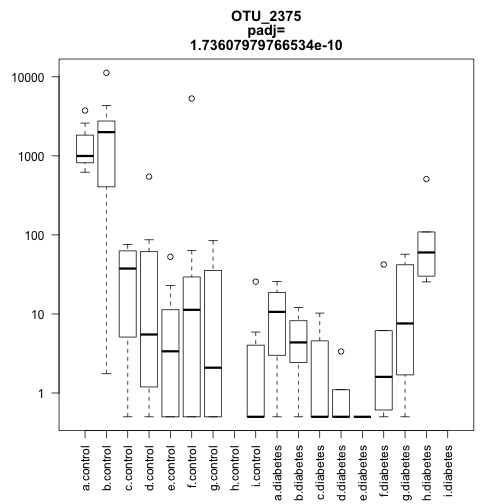

```r
padj_5<-plotCounts(skin_diff_dds, gene=row.names(resOrdered_skin)[5], intgroup=c("health","subject2"), returnData=TRUE)
boxplot(padj_5$count ~ padj_5$subject2*padj_5$health, log="y", las=2, main=c(row.names(resOrdered_skin)[5]," padj= ", resOrdered_skin$padj[5]))
```

```r
#Get relative abundances for OTUs per subject(?) and group for the sig diff OTUs
merge_skin<-merge_samples(mydata_sub_skin, "health")
#transform sample counts to %
mydata_sub_skin_relab<-transform_sample_counts(mydata_sub_skin, function(x) 100 * x/sum(x))
#Get vector of OTU names with p<0.05 in diff abundance analysis
OTUnames<-row.names(skin_sig)
#Get average abundance of each OTU across all skin samples
allsums<-(taxa_sums(mydata_sub_skin_relab)[OTUnames])
averagesums<-(taxa_sums(mydata_sub_skin_relab)[OTUnames])/nsamples(mydata_sub_skin)
allsums
```

```
##     OTU_108     OTU_146    OTU_1606      OTU_24    OTU_2375    OTU_3816
##  39.9136796  52.2462752  12.5521330  44.8650224  55.0443253   8.0774464
##    OTU_1589     OTU_465      OTU_18    OTU_2215     OTU_939     OTU_669
##   5.9803809   8.2498708  10.0678109   5.4593194  19.0462360   5.8153018
##    OTU_1005     OTU_166      OTU_34    OTU_6933     OTU_538    OTU_2463
##   2.3571291   6.1676297  50.2167356   8.0614061   4.3567592   2.4102319
##    OTU_1269    OTU_4961       OTU_4      OTU_13     OTU_301     OTU_825
##   5.6511158   1.6884621  30.3733369 142.8178989   1.4525282   1.1111315
##    OTU_1013    OTU_3757    OTU_1738    OTU_7964     OTU_850    OTU_1317
##   5.1932600   9.4345691   5.7052152   0.9823278  10.2623936   4.1671210
##     OTU_961    OTU_1469    OTU_1915    OTU_5314     OTU_352     OTU_421
##   6.7246088   2.2029715   0.8698240   1.4242072   3.0301000   2.9954243
##     OTU_276    OTU_4363      OTU_21    OTU_1413    OTU_1096    OTU_1461
##   2.8526555   1.9671691  88.4825150   0.7830977   8.9884192   2.8955904
##      OTU_49      OTU_68    OTU_1142    OTU_5047    OTU_7601    OTU_2340
##  23.5043515  38.1527551   3.9094785   1.9427464   2.4675465   4.9707260
##     OTU_672    OTU_1308     OTU_120    OTU_1195     OTU_307     OTU_398
##   1.5334775   1.0290170   3.5448545   0.8350768   2.0709440   2.2135488
##    OTU_1803     OTU_641     OTU_173    OTU_1370    OTU_1430     OTU_585
##   2.8411259   2.9282358   1.3106786   1.4381118   1.6747609   3.0214055
##     OTU_420    OTU_1198     OTU_429     OTU_395     OTU_497    OTU_3822
##   1.7806843   2.5860604  11.3877883   1.9259316   1.6905194   2.8382231
##    OTU_3021     OTU_725    OTU_1678    OTU_4098     OTU_295       OTU_6
##   0.6838908   0.8577026   1.4337563   6.6097661   3.4470383  72.4364324
##      OTU_62      OTU_83    OTU_1424    OTU_6365     OTU_491    OTU_1470
##  25.0548653   2.7145191   1.2765305   0.5963368   1.9197854   1.9613476
##     OTU_501     OTU_790    OTU_4475    OTU_2284    OTU_1094     OTU_327
##   4.3576225   0.9747289   1.9689679  18.6627229   5.0445706   6.0978365
##     OTU_201    OTU_1032      OTU_19    OTU_3815      OTU_39     OTU_182
##   3.2869643   4.6085208  22.4014564   1.7077551   2.8385630   1.3057286
##     OTU_426    OTU_1097
##   2.1468995   2.6987722
```

```r
averagesums
```

```
##     OTU_108     OTU_146    OTU_1606      OTU_24    OTU_2375    OTU_3816
## 0.327161309 0.428248157 0.102886336 0.367746085 0.451182995 0.066208577
##    OTU_1589     OTU_465      OTU_18    OTU_2215     OTU_939     OTU_669
## 0.049019516 0.067621891 0.082523040 0.044748519 0.156116688 0.047666408
##    OTU_1005     OTU_166      OTU_34    OTU_6933     OTU_538    OTU_2463
## 0.019320731 0.050554341 0.411612587 0.066077099 0.035711141 0.019755999
##    OTU_1269    OTU_4961       OTU_4      OTU_13     OTU_301     OTU_825
## 0.046320622 0.013839853 0.248961778 1.170638516 0.011905969 0.009107636
##    OTU_1013    OTU_3757    OTU_1738    OTU_7964     OTU_850    OTU_1317
## 0.042567705 0.077332533 0.046764059 0.008051867 0.084117981 0.034156729
##     OTU_961    OTU_1469    OTU_1915    OTU_5314     OTU_352     OTU_421
## 0.055119744 0.018057144 0.007129705 0.011673830 0.024836885 0.024552659
##     OTU_276    OTU_4363      OTU_21    OTU_1413    OTU_1096    OTU_1461
## 0.023382422 0.016124337 0.725266517 0.006418833 0.073675567 0.023734348
##      OTU_49      OTU_68    OTU_1142    OTU_5047    OTU_7601    OTU_2340
## 0.192658619 0.312727501 0.032044906 0.015924151 0.020225791 0.040743656
##     OTU_672    OTU_1308     OTU_120    OTU_1195     OTU_307     OTU_398
## 0.012569488 0.008434565 0.029056185 0.006844892 0.016974951 0.018143843
##    OTU_1803     OTU_641     OTU_173    OTU_1370    OTU_1430     OTU_585
## 0.023287917 0.024001933 0.010743268 0.011787802 0.013727548 0.024765619
##     OTU_420    OTU_1198     OTU_429     OTU_395     OTU_497    OTU_3822
## 0.014595773 0.021197216 0.093342527 0.015786324 0.013856716 0.023264124
##    OTU_3021     OTU_725    OTU_1678    OTU_4098     OTU_295       OTU_6
## 0.005605662 0.007030350 0.011752101 0.054178411 0.028254412 0.593741249
##      OTU_62      OTU_83    OTU_1424    OTU_6365     OTU_491    OTU_1470
## 0.205367749 0.022250156 0.010463365 0.004888006 0.015735946 0.016076619
##     OTU_501     OTU_790    OTU_4475    OTU_2284    OTU_1094     OTU_327
## 0.035718217 0.007989581 0.016139081 0.152973139 0.041348939 0.049982266
##     OTU_201    OTU_1032      OTU_19    OTU_3815      OTU_39     OTU_182
## 0.026942330 0.037774761 0.183618495 0.013997992 0.023266910 0.010702694
##     OTU_426    OTU_1097
## 0.017597537 0.022121084
```

```r
fivenum(allsums)
```

```
##    OTU_6365     OTU_420     OTU_421    OTU_6933      OTU_13
##   0.5963368   1.8502348   3.0084149   8.0694263 142.8178989
```

```r
fivenum(averagesums)
```

```
##    OTU_6365     OTU_420     OTU_421    OTU_6933      OTU_13
## 0.004888006 0.015165859 0.024659139 0.066142838 1.170638516
```

```r
#Now how to bind the average sums information to the table of OTUs with p<0.05 above?  Then I will know the average abundance (overall, not per group)
#Then to put the random forest analysis here:  will try to cut and paste from Sunaina's script and run it.

#Make a table comparing high GINI index organisms and diff abund OTUs found above with DESeq2.
#Then done with this section of the analysis!
#create vectors with names of control samples and diabetic samples for skin
control_skin_samples<-rownames(sample_data(mydata_sub_skin)[sample_data(mydata_sub_skin)[,"health"]=="control"])
diabetic_skin_samples<-rownames(sample_data(mydata_sub_skin)[sample_data(mydata_sub_skin)[,"health"]=="diabetes"])
#apply the mean & stdev functions to sig diff OTUs only, and for only control or skin samples
control_sig_otus_means<-as.matrix(apply(otu_table(mydata_sub_skin_relab)[OTUnames,control_skin_samples],1,FUN=mean))
control_sig_otus_sd<-as.matrix(apply(otu_table(mydata_sub_skin_relab)[OTUnames,control_skin_samples],1,FUN=sd))
diabetic_sig_otus_means<-as.matrix(apply(otu_table(mydata_sub_skin_relab)[OTUnames,diabetic_skin_samples],1,FUN=mean))
diabetic_sig_otus_sd<-as.matrix(apply(otu_table(mydata_sub_skin_relab)[OTUnames,diabetic_skin_samples],1,FUN=sd))
#Create a table of sig dif OTU names, taxa, adjp values, and average relative abundance for both eeach of control and diabetic skin groups.
#First make sure sig otu means values are in the same order as the results of sig dif test
control_sig_otus_means<-as.matrix(control_sig_otus_means[(rownames(skin_diff_merge)),])
control_sig_otus_sd<-as.matrix(control_sig_otus_sd[(rownames(skin_diff_merge)),])
diabetic_sig_otus_means<-as.matrix(diabetic_sig_otus_means[(rownames(skin_diff_merge)),])
diabetic_sig_otus_sd<-as.matrix(diabetic_sig_otus_sd[(rownames(skin_diff_merge)),])
#Now bind average abundances and sd to the results table
sig_diff_otus_results<-cbind(skin_diff_merge,control_sig_otus_means,control_sig_otus_sd, diabetic_sig_otus_means, diabetic_sig_otus_sd)
sig_diff_otus_results[order(-sig_diff_otus_results$control_sig_otus_means),]
```

```
##               Domain              Phylum                    Class
## OTU_13   k__Bacteria   p__Actinobacteria        c__Actinobacteria
## OTU_21   k__Bacteria   p__Actinobacteria        c__Actinobacteria
## OTU_6    k__Bacteria   p__Proteobacteria   c__Gammaproteobacteria
## OTU_2375 k__Bacteria   p__Actinobacteria        c__Actinobacteria
## OTU_146  k__Bacteria   p__Actinobacteria        c__Actinobacteria
## OTU_34   k__Bacteria   p__Actinobacteria        c__Actinobacteria
## OTU_108  k__Bacteria   p__Actinobacteria        c__Actinobacteria
## OTU_24   k__Bacteria   p__Actinobacteria        c__Actinobacteria
## OTU_68   k__Bacteria       p__Firmicutes               c__Bacilli
## OTU_49   k__Bacteria   p__Proteobacteria   c__Alphaproteobacteria
## OTU_62   k__Bacteria   p__Proteobacteria   c__Gammaproteobacteria
## OTU_939  k__Bacteria   p__Actinobacteria        c__Actinobacteria
## OTU_19   k__Bacteria       p__Firmicutes               c__Bacilli
## OTU_4    k__Bacteria   p__Actinobacteria        c__Actinobacteria
## OTU_1606 k__Bacteria   p__Proteobacteria   c__Alphaproteobacteria
## OTU_18   k__Bacteria   p__Proteobacteria   c__Alphaproteobacteria
## OTU_3757 k__Bacteria       p__Firmicutes               c__Bacilli
## OTU_3816 k__Bacteria       p__Firmicutes               c__Bacilli
## OTU_465  k__Bacteria    p__Bacteroidetes        c__Flavobacteriia
## OTU_2284 k__Bacteria   p__Proteobacteria   c__Alphaproteobacteria
## OTU_1096 k__Bacteria   p__Proteobacteria   c__Alphaproteobacteria
## OTU_850  k__Bacteria    p__Bacteroidetes      c__Sphingobacteriia
## OTU_166  k__Bacteria         p__[Thermi]            c__Deinococci
## OTU_1589 k__Bacteria   p__Actinobacteria        c__Actinobacteria
## OTU_6933 k__Bacteria    p__Bacteroidetes        c__Flavobacteriia
## OTU_4098 k__Bacteria   p__Actinobacteria        c__Actinobacteria
## OTU_669  k__Bacteria         p__[Thermi]            c__Deinococci
## OTU_429  k__Bacteria   p__Actinobacteria        c__Actinobacteria
## OTU_1269 k__Bacteria         p__[Thermi]            c__Deinococci
## OTU_2215 k__Bacteria         p__[Thermi]            c__Deinococci
## OTU_1013 k__Bacteria   p__Proteobacteria   c__Alphaproteobacteria
## OTU_2340 k__Bacteria   p__Actinobacteria        c__Actinobacteria
## OTU_1032 k__Bacteria    p__Cyanobacteria           c__Chloroplast
## OTU_1094 k__Bacteria   p__Actinobacteria        c__Actinobacteria
## OTU_538  k__Bacteria       p__Firmicutes               c__Bacilli
## OTU_961  k__Bacteria   p__Proteobacteria   c__Alphaproteobacteria
## OTU_1738 k__Bacteria   p__Actinobacteria        c__Actinobacteria
## OTU_327  k__Bacteria   p__Proteobacteria   c__Gammaproteobacteria
## OTU_1142 k__Bacteria   p__Proteobacteria   c__Alphaproteobacteria
```

[output cut: 410 more lines]

```
## OTU_1370         0.040100912            0.0093840595          0.030438395
## OTU_641          0.026790691            0.0468537352          0.099970437
## OTU_352          0.033040018            0.0497271686          0.153292660
## OTU_39           0.040073531            0.0464002050          0.114978658
## OTU_7964         0.029578748            0.0017208852          0.004170246
## OTU_1915         0.016869002            0.0023067961          0.004701068
## OTU_790          0.020648004            0.0060051996          0.022349176
## OTU_1195         0.015041526            0.0037154620          0.010818003
## OTU_1308         0.021791396            0.0094639784          0.022513702
## OTU_1413         0.024191018            0.0037343106          0.016327908
## OTU_3021         0.016372999            0.0014439273          0.005780165
## OTU_1470         0.012458911            0.0361732685          0.133103879
## OTU_725          0.016444135            0.0096204269          0.023622278
## OTU_501          0.010998704            0.0951314050          0.489537463
## OTU_6365         0.009856469            0.0059480925          0.021266682
```

Plots of Relative abundance of OTUs of interest per subject

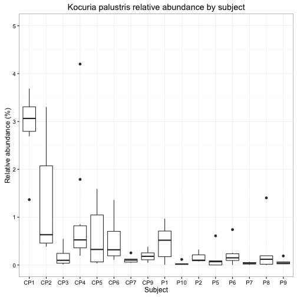

```r
OTU_13<-data.frame(otu_table(rare_skin)["OTU_13",])
OTU_13<-t(OTU_13)
OTU_13<-OTU_13[order(rownames(OTU_13)),,drop=FALSE]
subject<-sample_data(rare_skin)[order(rownames(sample_data(rare_skin))),"subject"]
OTU_13<-cbind(OTU_13,subject)
OTU_13$"OTU_13"<-(OTU_13$"OTU_13"/30000)*100
ggplot(OTU_13, aes(x=subject, y=OTU_13)) +
  geom_boxplot()+ylim(0,5)+labs(x = "Subject", y="Relative abundance (%)")+
  ggtitle("Kocuria palustris relative abundance by subject")
```

```r
OTU_1002005<-data.frame(otu_table(rare_skin)["1002005",])
```

```
## Error in as(x, "matrix")[i, j, drop = FALSE]: subscript out of bounds
```

```r
OTU_1002005<-t(OTU_1002005)
```

```
## Error in t(OTU_1002005): error in evaluating the argument 'x' in selecting a method for function 't': Error: object 'OTU_1002005' not found
```

```r
OTU_1002005<-OTU_1002005[order(rownames(OTU_1002005)),,drop=FALSE]
```

```
## Error in eval(expr, envir, enclos): object 'OTU_1002005' not found
```

```r
subject<-sample_data(rare_skin)[order(rownames(sample_data(rare_skin))),"subject"]
OTU_1002005<-cbind(OTU_1002005,subject)
```

```
## Error in eval(expr, envir, enclos): object 'OTU_1002005' not found
```

```r
OTU_1002005$"1002005"<-(OTU_1002005$"1002005"/30000)*100
```

```
## Error in eval(expr, envir, enclos): object 'OTU_1002005' not found
```

```r
ggplot(OTU_1002005, aes(x=subject, y=OTU_1002005$"1002005")) +
  geom_boxplot()+ylim(0,5)+labs(x = "Subject", y="Relative abundance (%)")+
  ggtitle("Kocuria palustris relative abundance by subject")
```

```
## Error in ggplot(OTU_1002005, aes(x = subject, y = OTU_1002005$"1002005")): object 'OTU_1002005' not found
```

```r
OTU_2855257<-data.frame(otu_table(rare_skin)["2855257",])
```

```
## Error in as(x, "matrix")[i, j, drop = FALSE]: subscript out of bounds
```

```r
OTU_2855257<-t(OTU_2855257)
```

```
## Error in t(OTU_2855257): error in evaluating the argument 'x' in selecting a method for function 't': Error: object 'OTU_2855257' not found
```

```r
OTU_2855257<-OTU_2855257[order(rownames(OTU_2855257)),,drop=FALSE]
```

```
## Error in eval(expr, envir, enclos): object 'OTU_2855257' not found
```

```r
OTU_2855257<-cbind(OTU_2855257,subject)
```

```
## Error in eval(expr, envir, enclos): object 'OTU_2855257' not found
```

```r
OTU_2855257$"2855257"<-(OTU_2855257$"2855257"/30000)*100
```

```
## Error in eval(expr, envir, enclos): object 'OTU_2855257' not found
```

```r
ggplot(OTU_2855257, aes(x=subject, y=OTU_2855257$"2855257")) +
  geom_boxplot()+ylim(0,0.25)+labs(x = "Subject", y="Relative abundance (%)")+ggtitle("Modestobacter relative abundance by subject")
```

```
## Error in ggplot(OTU_2855257, aes(x = subject, y = OTU_2855257$"2855257")): object 'OTU_2855257' not found
```

```r
OTU_205559<-data.frame(otu_table(rare_skin)["205559",])
```

```
## Error in as(x, "matrix")[i, j, drop = FALSE]: subscript out of bounds
```

```r
OTU_205559<-t(OTU_205559)
```

```
## Error in t(OTU_205559): error in evaluating the argument 'x' in selecting a method for function 't': Error: object 'OTU_205559' not found
```

```r
OTU_205559<-OTU_205559[order(rownames(OTU_205559)),,drop=FALSE]
```

```
## Error in eval(expr, envir, enclos): object 'OTU_205559' not found
```

```r
OTU_205559<-cbind(OTU_205559,subject)
```

```
## Error in eval(expr, envir, enclos): object 'OTU_205559' not found
```

```r
OTU_205559$"205559"<-(OTU_205559$"205559"/30000)*100
```

```
## Error in eval(expr, envir, enclos): object 'OTU_205559' not found
```

```r
ggplot(OTU_205559, aes(x=subject, y=OTU_205559$"205559")) +
  geom_boxplot()+ylim(0,0.055)+labs(x = "Subject", y="Relative abundance (%)")+ggtitle("Microbacteriaceae relative abundance by subject")
```

```
## Error in ggplot(OTU_205559, aes(x = subject, y = OTU_205559$"205559")): object 'OTU_205559' not found
```

```r
#Highest by GINI index
OTU_16101<-data.frame(otu_table(rare_skin)["16101",])
```

```
## Error in as(x, "matrix")[i, j, drop = FALSE]: subscript out of bounds
```

```r
OTU_16101<-t(OTU_16101)
```

```
## Error in t(OTU_16101): error in evaluating the argument 'x' in selecting a method for function 't': Error: object 'OTU_16101' not found
```

```r
OTU_16101<-OTU_16101[order(rownames(OTU_16101)),,drop=FALSE]
```

```
## Error in eval(expr, envir, enclos): object 'OTU_16101' not found
```

```r
OTU_16101<-cbind(OTU_16101,subject)
```

```
## Error in eval(expr, envir, enclos): object 'OTU_16101' not found
```

```r
OTU_16101$"16101"<-(OTU_16101$"16101"/30000)*100
```

```
## Error in eval(expr, envir, enclos): object 'OTU_16101' not found
```

```r
ggplot(OTU_16101, aes(x=subject, y=OTU_16101$"16101")) +
  geom_boxplot()+ylim(0,0.15)+labs(x = "Subject", y="Relative abundance (%)")+ggtitle("Caldicellulosiruptor saccharolyticus relative abundance by subject")
```

```
## Error in ggplot(OTU_16101, aes(x = subject, y = OTU_16101$"16101")): object 'OTU_16101' not found
```

#Now for random forrest - can I paste Sunaina's script here? Let's see…. ##Loading packages and data files in phyloseq

###Basic Random Forest

```r
wh0 = genefilter_sample(rare_skin, filterfun_sample(function(x) x > 0), A = 0.10 * nsamples(rare_skin))
rare_skin_filter <- prune_taxa(wh0, rare_skin)
```

[output not shown]

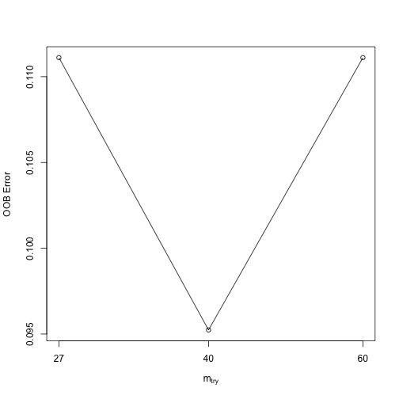

```
##        mtry  OOBError
## 27.OOB   27 0.1111111
## 40.OOB   40 0.0952381
## 60.OOB   60 0.1111111
```

```
## [1] 40
```

```
## Confusion Matrix and Statistics
##
##           Reference
## Prediction diabetes control
##   diabetes        9      11
##   control        15      24
##
##                Accuracy : 0.5593
##                  95% CI : (0.424, 0.6884)
##     No Information Rate : 0.5932
##     P-Value [Acc > NIR] : 0.7475
##
##                   Kappa : 0.0623
##  Mcnemar's Test P-Value : 0.5563
##
##             Sensitivity : 0.3750
##             Specificity : 0.6857
##          Pos Pred Value : 0.4500
##          Neg Pred Value : 0.6154
##              Prevalence : 0.4068
##          Detection Rate : 0.1525
##    Detection Prevalence : 0.3390
##       Balanced Accuracy : 0.5304
##
##        'Positive' Class : diabetes
##
```

###Naive Bayes

```
## Confusion Matrix and Statistics
##
##           Reference
## Prediction diabetes control
##   diabetes       10      10
##   control        17      22
##
##                Accuracy : 0.5424
##                  95% CI : (0.4075, 0.6728)
##     No Information Rate : 0.5424
##     P-Value [Acc > NIR] : 0.5533
##
##                   Kappa : 0.0591
##  Mcnemar's Test P-Value : 0.2482
##
##             Sensitivity : 0.3704
##             Specificity : 0.6875
##          Pos Pred Value : 0.5000
##          Neg Pred Value : 0.5641
##              Prevalence : 0.4576
##          Detection Rate : 0.1695
##    Detection Prevalence : 0.3390
##       Balanced Accuracy : 0.5289
##
##        'Positive' Class : diabetes
##
```

###rpart

```
## Confusion Matrix and Statistics
##
##           Reference
## Prediction diabetes control
##   diabetes       15       5
##   control        22      17
##
##                Accuracy : 0.5424
##                  95% CI : (0.4075, 0.6728)
##     No Information Rate : 0.6271
##     P-Value [Acc > NIR] : 0.929243
##
##                   Kappa : 0.154
##  Mcnemar's Test P-Value : 0.002076
##
##             Sensitivity : 0.4054
##             Specificity : 0.7727
##          Pos Pred Value : 0.7500
##          Neg Pred Value : 0.4359
##              Prevalence : 0.6271
##          Detection Rate : 0.2542
##    Detection Prevalence : 0.3390
##       Balanced Accuracy : 0.5891
##
##        'Positive' Class : diabetes
##
```

###Finding important predictors for RF using Gini importance

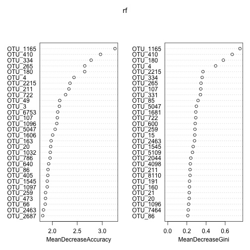

```r
#Define list of OTUs of interest - from a spreadsheet comparing results from Kruskal and Wallice tst for significant differences, and Gini Index
sig_otus_interest<-c("274011","818388","2855257","New.CleanUp.ReferenceOTU10998","948180","205559","1002005","1048194","993474","569992","New.ReferenceOTU181","403359","4418684","New.ReferenceOTU153","688714","952388","1093944","369436","552687","1108726","349901","16101")
abund_sig_otus_interest<-average_abund_sd_skin[sig_otus_interest,]
```

```
## Error in average_abund_sd_skin[sig_otus_interest, ]: subscript out of bounds
```

```r
tax_sig_otus_interest<-tax_table(rare_mydata_sub)[sig_otus_interest,]
```

```
## Error in tax_table(as(x, "matrix")[i, j, drop = FALSE]): error in evaluating the argument 'object' in selecting a method for function 'tax_table': Error in as(x, "matrix")[i, j, drop = FALSE] : subscript out of bounds
```

```r
abund_sig_otus_interest<-as.matrix(cbind(abund_sig_otus_interest,tax_sig_otus_interest))
```

[output not shown]

```r
abund_sig_otus_interest
```

```
## Error in eval(expr, envir, enclos): object 'abund_sig_otus_interest' not found
```

```r
#Now get abundance for GINI indext sig results.
gini_otus_abund<-average_abund_sd_skin[otunames,]
tax_gini_otus<-tax_table(rare_mydata_sub)[otunames,]
gini_otus_abund<-cbind(gini_otus_abund,tax_gini_otus)
```